# Question

Match the following equations to their graphs.

1. $y=- \frac{\left(x - 2\right) \left(x + 2\right)}{2}$
2. $y=\frac{\left(x - 5\right) \left(x + 3\right)}{8}$
3. $y=- \frac{\left(x - 4\right) \left(x + 4\right)}{2}$
4. $y=- \frac{3 \left(x - 5\right) \left(x + 3\right)}{8}$

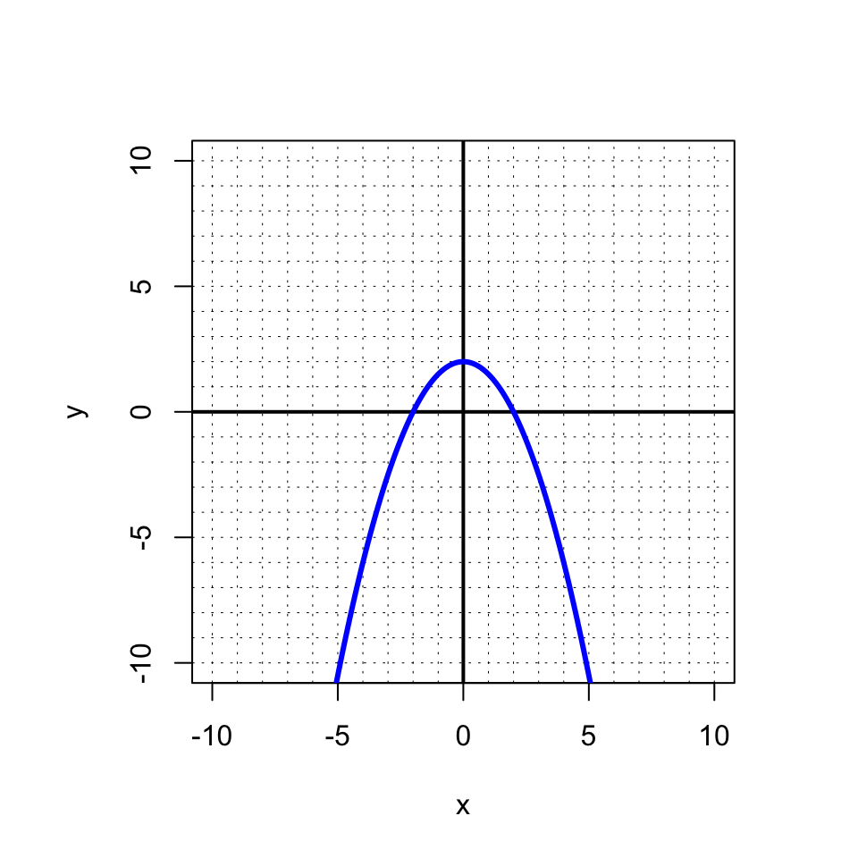

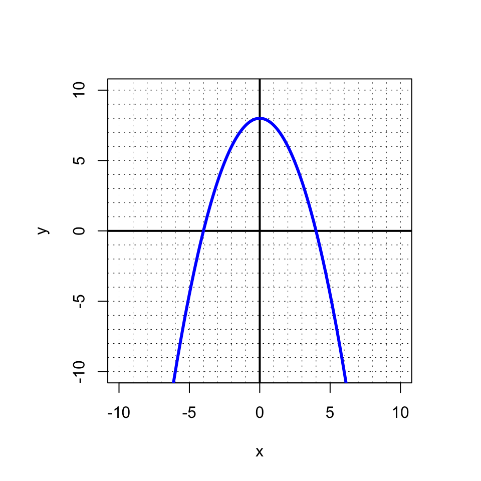

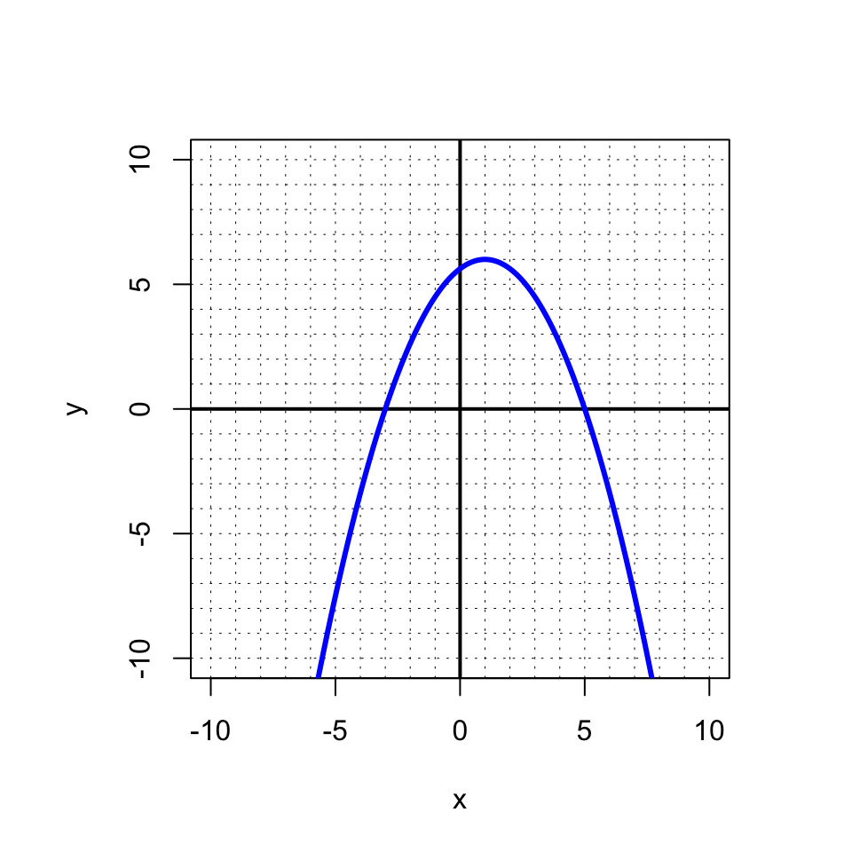

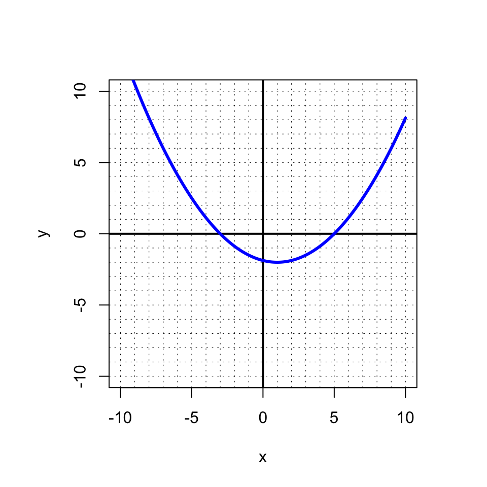

## Answerlist

- y=-(x - 2)*(x + 2)/2
- y=(x - 5)*(x + 3)/8
- y=-(x - 4)*(x + 4)/2
- y=-3*(x - 5)*(x + 3)/8
- y=-(x - 2)*(x + 2)/2
- y=(x - 5)*(x + 3)/8
- y=-(x - 4)*(x + 4)/2
- y=-3*(x - 5)*(x + 3)/8
- y=-(x - 2)*(x + 2)/2
- y=(x - 5)*(x + 3)/8
- y=-(x - 4)*(x + 4)/2
- y=-3*(x - 5)*(x + 3)/8
- y=-(x - 2)*(x + 2)/2
- y=(x - 5)*(x + 3)/8
- y=-(x - 4)*(x + 4)/2
- y=-3*(x - 5)*(x + 3)/8

# Solution

1. The first graph has roots at -2 and 2. Notice the equation $- \frac{\left(x - 2\right) \left(x + 2\right)}{2}$ has factors that match those roots. Also, notice the parabola faces downward, and the expression has a negative multiplicative coefficient.
2. The second graph has roots at 4 and -4. Notice the equation $- \frac{\left(x - 4\right) \left(x + 4\right)}{2}$ has factors that match those roots. Also, notice the parabola faces downward, and the expression has a negative multiplicative coefficient.
3. The third graph has roots at 5 and -3. Notice the equation $- \frac{3 \left(x - 5\right) \left(x + 3\right)}{8}$ has factors that match those roots. Also, notice the parabola faces downward, and the expression has a negative multiplicative coefficient.
4. The fourth graph has roots at -3 and 5. Notice the equation $\frac{\left(x - 5\right) \left(x + 3\right)}{8}$ has factors that match those roots. Also, notice the parabola faces upward, and the expression has a positive multiplicative coefficient.

# Meta-information